# Technical Analysis: DATS 6101 Final Project

## Verifying training and testing data

Here we view our training and testing dataset to ensure that it represents correct portions of the original dataset. We are inspecting our training anf testing dataset to ensure they look normal and to make sure they were created correctly.

```r
summary(training)
```

```
##                derived_ethnicity                           derived_race
##  Ethnicity Not Available:1165    White                           :4881
##  Hispanic or Latino     :1821    Race Not Available              :1363
##  Joint                  : 455    Asian                           :1134
##  Not Hispanic or Latino :5320    Black or African American       : 752
##                                  Joint                           : 399
##                                  American Indian or Alaska Native:  96
##                                  (Other)                         : 136
##             derived_sex   action_taken  loan_amount     interest_rate
##  Female           :1987   0:4390       Min.   :  5000   Min.   :2.50
##  Joint            :3447   1:4371       1st Qu.:105000   1st Qu.:3.88
##  Male             :2871                Median :285000   Median :4.46
##  Sex Not Available: 456                Mean   :292836   Mean   :4.26
##                                        3rd Qu.:435000   3rd Qu.:4.46
##                                        Max.   :955000   Max.   :6.12
##
##  property_value        income    applicant_age      prob         income_sc.V1
##  Min.   :  15000   Min.   :-19   <25  : 106    Min.   :0.032   Min.   :-2.124
##  1st Qu.: 375000   1st Qu.: 59   >74  : 542    1st Qu.:0.318   1st Qu.:-0.732
##  Median : 495000   Median : 94   25-34:1527    Median :0.518   Median :-0.107
##  Mean   : 521724   Mean   :100   35-44:2121    Mean   :0.499   Mean   : 0.001
##  3rd Qu.: 645000   3rd Qu.:134   45-54:1941    3rd Qu.:0.673   3rd Qu.: 0.607
##  Max.   :1195000   Max.   :263   55-64:1465    Max.   :0.982   Max.   : 2.910
##                                  65-74:1059
##  interest_sc.V1  property_sc.V1  loan_amount_sc.V1     prob1
##  Min.   :-3.06   Min.   :-2.45   Min.   :-1.46     Min.   :0.032
##  1st Qu.:-0.67   1st Qu.:-0.71   1st Qu.:-0.95     1st Qu.:0.318
##  Median : 0.34   Median :-0.13   Median :-0.04     Median :0.518
##  Mean   :-0.01   Mean   : 0.00   Mean   : 0.00     Mean   :0.499
##  3rd Qu.: 0.34   3rd Qu.: 0.60   3rd Qu.: 0.72     3rd Qu.:0.673
##  Max.   : 3.23   Max.   : 3.26   Max.   : 3.35     Max.   :0.982
##
```

```r
summary(testing)
```

```
##                derived_ethnicity
##  Ethnicity Not Available: 285
##  Hispanic or Latino     : 458
##  Joint                  : 116
##  Not Hispanic or Latino :1332
##
##
##
##                                     derived_race             derived_sex
##  White                                    :1223   Female           :426
##  Race Not Available                       : 351   Joint            :884
##  Asian                                    : 265   Male             :779
##  Black or African American                : 181   Sex Not Available:102
##  Joint                                    :  95
##  Native Hawaiian or Other Pacific Islander:  34
##  (Other)                                  :  42
##  action_taken  loan_amount     interest_rate  property_value        income
##  0:1086       Min.   :  5000   Min.   :2.50   Min.   :  55000   Min.   :-12.0
##  1:1105       1st Qu.:105000   1st Qu.:3.99   1st Qu.: 365000   1st Qu.: 60.0
##               Median :285000   Median :4.46   Median : 495000   Median : 93.0
##               Mean   :292010   Mean   :4.28   Mean   : 520208   Mean   : 99.7
##               3rd Qu.:445000   3rd Qu.:4.46   3rd Qu.: 645000   3rd Qu.:135.0
##               Max.   :965000   Max.   :6.12   Max.   :1195000   Max.   :263.0
##
##  applicant_age      prob         income_sc.V1   interest_sc.V1  property_sc.V1
##  <25  : 29     Min.   :0.033   Min.   :-1.999   Min.   :-3.06   Min.   :-2.26
##  >74  :133     1st Qu.:0.324   1st Qu.:-0.714   1st Qu.:-0.47   1st Qu.:-0.76
##  25-34:372     Median :0.519   Median :-0.125   Median : 0.34   Median :-0.13
##  35-44:524     Mean   :0.505   Mean   :-0.005   Mean   : 0.03   Mean   :-0.01
##  45-54:494     3rd Qu.:0.684   3rd Qu.: 0.625   3rd Qu.: 0.34   3rd Qu.: 0.60
##  55-64:368     Max.   :0.973   Max.   : 2.910   Max.   : 3.23   Max.   : 3.26
##  65-74:271
##  loan_amount_sc.V1     prob1
##  Min.   :-1.46     Min.   :0.033
##  1st Qu.:-0.95     1st Qu.:0.324
##  Median :-0.04     Median :0.519
##  Mean   : 0.00     Mean   :0.505
##  3rd Qu.: 0.77     3rd Qu.:0.684
##  Max.   : 3.40     Max.   :0.973
##
```

```r
hmda_glm_back <- step(hmda_glm0) #backward selections
summary(hmda_glm_back)
hmda_glm_back$deviance
AIC(hmda_glm_back)
```

## Predictive Analysis and Confusion Matrix

This is where we implement our test and train dataset in order to check our predictions and to see how well our model is preforming. We already used feature selection and found the right varibles needed so now we score our model to ensure it is giving us the right results.

```r
library(caret)
glm_fit = glm(action_taken ~ derived_race + derived_ethnicity + loan_amount+applicant_age+ income+interest_rate+property_value, data = training, family = "binomial")
summ(glm_fit)
```

| Observations | 8761 |
| --- | --- |
| Dependent variable | action_taken |
| Type | Generalized linear model |
| Family | binomial |
| Link | logit |

| 𝛘²(20) | 1869.46 |
| --- | --- |
| Pseudo-R² (Cragg-Uhler) | 0.26 |
| Pseudo-R² (McFadden) | 0.15 |
| AIC | 10317.83 |
| BIC | 10466.47 |

|  | Est. | S.E. | z val. | p |
| --- | --- | --- | --- | --- |
| (Intercept) | -3.99 | 0.48 | -8.36 | 0.00 |
| derived_raceAmerican Indian or Alaska Native | -0.62 | 0.42 | -1.46 | 0.14 |
| derived_raceAsian | -0.79 | 0.35 | -2.24 | 0.03 |
| derived_raceBlack or African American | -0.30 | 0.36 | -0.84 | 0.40 |
| derived_raceJoint | -0.80 | 0.36 | -2.21 | 0.03 |
| derived_raceNative Hawaiian or Other Pacific Islander | -0.33 | 0.43 | -0.76 | 0.44 |
| derived_raceRace Not Available | -0.97 | 0.36 | -2.71 | 0.01 |
| derived_raceWhite | -1.53 | 0.35 | -4.40 | 0.00 |
| derived_ethnicityHispanic or Latino | 0.34 | 0.11 | 3.19 | 0.00 |
| derived_ethnicityJoint | 0.28 | 0.15 | 1.89 | 0.06 |
| derived_ethnicityNot Hispanic or Latino | -0.03 | 0.11 | -0.31 | 0.75 |
| loan_amount | -0.00 | 0.00 | -14.85 | 0.00 |
| applicant_age>74 | -0.35 | 0.24 | -1.46 | 0.14 |
| applicant_age25-34 | 0.26 | 0.22 | 1.15 | 0.25 |
| applicant_age35-44 | 0.55 | 0.22 | 2.48 | 0.01 |
| applicant_age45-54 | 0.58 | 0.22 | 2.63 | 0.01 |
| applicant_age55-64 | 0.51 | 0.22 | 2.29 | 0.02 |
| applicant_age65-74 | 0.25 | 0.23 | 1.11 | 0.27 |
| income | -0.00 | 0.00 | -7.90 | 0.00 |
| interest_rate | 1.28 | 0.05 | 26.20 | 0.00 |
| property_value | 0.00 | 0.00 | 3.47 | 0.00 |

Standard errors: MLE

```r
glm_probs = data.frame(probs = predict(glm_fit,
                                       newdata = testing,
                                       type="response"))

glm_pred = glm_probs %>%
  mutate(pred = ifelse(probs>.5, "1", "0"))



pc<-factor(glm_pred$pred)
e<- (testing$action_taken)


table(pc)
```

```
## pc
##    0    1
## 1039 1152
```

```r
table(e)
```

```
## e
##    0    1
## 1086 1105
```

```r
confusionMatrix(data=pc, reference = e)
```

```
## Confusion Matrix and Statistics
##
##           Reference
## Prediction   0   1
##          0 754 285
##          1 332 820
##
##                Accuracy : 0.718
##                  95% CI : (0.699, 0.737)
##     No Information Rate : 0.504
##     P-Value [Acc > NIR] : <2e-16
##
##                   Kappa : 0.437
##
##  Mcnemar's Test P-Value : 0.064
##
##             Sensitivity : 0.694
##             Specificity : 0.742
##          Pos Pred Value : 0.726
##          Neg Pred Value : 0.712
##              Prevalence : 0.496
##          Detection Rate : 0.344
##    Detection Prevalence : 0.474
##       Balanced Accuracy : 0.718
##
##        'Positive' Class : 0
##
```

[figure not shown]

```r
x<-data.frame("target"=c(1,0,1,0), "prediction"=c(1,1,0,0), "n"=c(817,306,288,786))

library(ggplot2)

ggplot(x, aes(x = target, y = prediction, fill = n)) +
  geom_tile(color = "black") +
  geom_text(aes(label = n), color = "Yellow", size = 4) +
  coord_fixed()+
  scale_fill_gradient2(low = "#075AFF",
                       mid = "#FFFFCC",
                       high = "Purple") +
     scale_y_continuous(trans = "reverse", breaks = unique(x$prediction))
```

# VI. Classification Trees

## Split Data (training:testing = 80%:20%)

```r
n = nrow(hmda_down)
split = sample(c(TRUE, FALSE), n, replace=TRUE, prob=c(0.8, 0.2))

tree.training = hmda_down[split, ]
tree.testing = hmda_down[!split, ]
```

In order to avoid overfitting the model we split the balanced dataset as 80% training set and 20% testing set.

## Decision Tree Model

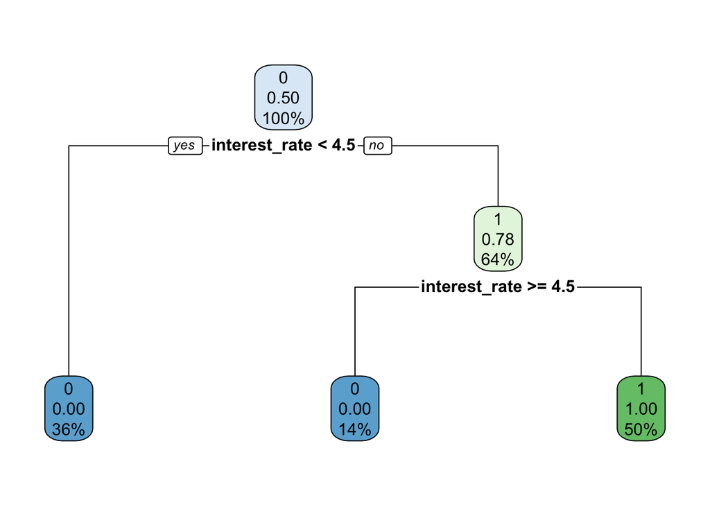

```r
library(rpart)
library(rpart.plot)
fit <- rpart(action_taken~ derived_race + derived_ethnicity + loan_amount+applicant_age+ income+interest_rate+property_value, data = tree.training, method = 'class',control = ("maxdepth = 4"))
rpart.plot(fit, extra = 106)
```

The predictors that are used in previous logistic models are used in decision tree model now.

## Making a Prediction

```r
predict_unseen <-predict(fit, tree.testing, type = 'class')
summary(predict_unseen)
```

```
##    0    1
## 1099 1104
```

## Create a table to count how many applicants are classified as approval and denied

```r
table_mat <- table(tree.testing$action_taken, predict_unseen )
table_mat
```

```
##    predict_unseen
##        0    1
##   0 1099    0
##   1    0 1104
```

## Measure Performance: Confusion Martrix

```r
accuracy_Test <- sum(diag(table_mat)) / sum(table_mat)#0.999
```

# VII. Conclusion and Next Steps

We have reached the following conclusions in our project. First, while literature reviewed and economic theory led us to the selection of our predictor variables, the model did not turn out to be a good fit. The McFadden value and the area under curve (AUC) both need to be improved in order for our model to be definitely used to answer our SMART question. Nevertheless, via feature selection, we at least know that ethnicity, race, sex, loan amount, interest rate, property value, income, and age are important to some degree to likelihood of loan denials in California in 2019. Thus, we argue that all of the predictor variables we tested should be included in future analyses. Second, our classification tree highlighted interest rate as an important factor for likelihood of a loan denial. In the real world, interest rate assigned to a mortgage is both largely determined by an applicant’s income and property value while also serving as a predictor of risk: the higher the interest rate, the riskier the lender deems the loan to be. We also know that, in the real world, income (which impacts interest rate) serves as a proxy for other factors and is often correlated with the race, ethnicity or sex of the individual in question. In short, it’s very difficult to disentagle these factors when they are so interrelated, and further study is warranted.

Were we to continue our analysis, we would determine whether interest rates are assigned only to loans that were approved and adjust our models and trees accordingly. We would also possibly consider removing it as a predictor, even though it is useful for correlation and general inference in the EDA phase.

# References

Bayer, P., Ferreira, F., and Ross, S..( 2014). Race, Ethnicity and High-Cost Mortgage Lending. NBER Working Paper No. 20762

Namin, S., Zhou,Y., Xu, W., McGinley, E., Jankowski,C., Laud, P., & Beyer, K. (2022)Persistence of mortgage lending bias in the United States: 80 years after the Home Owners’ Loan Corporation security maps, Journal of Race, Ethnicity and the City, DOI: 10.1080/26884674.2021.2019568

Park, K. A., (2022) A Comparison of Mortgage Denial and Default Rates by Race, Ethnicity, and Gender. Available at SSRN: https://ssrn.com/abstract=4030908 or http://dx.doi.org/10.2139/ssrn.4030908

California’s Population. Website title:Public Policy Institute of California URL:https://www.ppic.org/publication/californias-population/ Date accessed:March 21, 2022

Steil, J. P., Albright, L., Rugh, J. S., & Massey, D. S. (2018). The Social Structure of Mortgage Discrimination. Housing studies, 33(5), 759–776. https://doi.org/10.1080/02673037.2017.1390076

Kaul, K., Zhu, L. (2021). Mortgage Denial Rates and Household Finances among Older Americans. The Urban Institute. Accessible at: https://www.urban.org/sites/default/files/publication/104965/mortgage-denial-rates-and-household-finances-among-older-americans.pdf

# Data

Loan/Application Records (LAR). 2019. Dynamic National Loan-Level Dataset. Home Mortgage Disclosure Act (HMDA). Accessible at: https://ffiec.cfpb.gov/data-publication/dynamic-national-loan-level-dataset/2019